# Space Launches

## What is the name of agency that has the highest number of launches?

Find the agency with the highest number of launches

```r
launches_filtered <- launches %>%
  filter(!is.na(agency), launch_year >= 1957, launch_year <= 2018)
```

```r
launches_by_agency <- launches_filtered %>%
  group_by(agency) %>%
  summarize(num_launches = n())
```

### Find the agency with the highest number of launches.

Us agency has the higher number of launches according this code.

```r
max_launches_agency <- launches_by_agency[which.max(launches_by_agency$num_launches), ]
print(max_launches_agency$agency)
```

```
[1] "US"
```

```r
print(max_launches_agency$num_launches)
```

```
[1] 1202
```

Notice: After filtering launches between 1957 and 2018, we see that the United States have the highest number of launches with 1202 laumches during this period.

### Visualization data

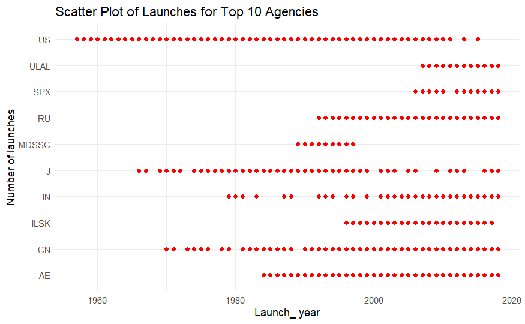

```r
ggplot(data = launches_no_missing %>% filter(agency %in% top_agencies$agency), aes(x = launch_year, y = agency)) +
  geom_point(color = "red") +
  labs(title = "Scatter Plot of Launches for Top 10 Agencies",
        x = "Launch_ year",
        y = "Number of launches") +
  theme_minimal()
```

In summary, the table provides a snapshot of the major contributors to space launches, showcasing the diverse participation of countries and private entities in space exploration. The high number of launches by the United States, Russia, China, and prominent private companies underscores the dynamic and evolving nature of space endeavors on a global scale.